# exp3_analysis

Set wd

```r
library(knitr)
opts_knit$set(root.dir = '/Users/rxdh/Box Sync/stanford/research/goodman/q&a/experiment1/')
setwd("/Users/rxdh/Box Sync/stanford/research/goodman/q&a/experiment1/")
library(tidyr)
library(plyr)
library(dplyr)
```

```r
library(ggplot2)
library(MultinomialCI)
```

## Experiment data analysis

Load and clean data. We remove people who self-identify as ‘confused’

```r
d1 = read.csv("versions/experiment1_replication_v2/data/q_and_a3_short-trials.tsv",  sep = '\t')
# Remove people who were confused...
ps1 = read.csv("versions/experiment1_replication_v2/data/q_and_a3_short-subject_information.tsv", sep = '\t')
# we only want to exclude people who specifically recorded that they were confused,
# keeping people who just left the response box blank.
nonconfused_ps1 <- (ps1 %>%
                   mutate(asses2 = ifelse(is.na(asses), "None", asses)) %>%
                   filter(asses2 != 1))$workerid
d1 = filter(d1, workerid %in% nonconfused_ps1)

d2 = read.csv("versions/experiment1_short/data/q_and_a3_short-trials.tsv",  sep = '\t')
ps2 = read.csv("versions/experiment1_short/data/q_and_a3_short-subject_information.tsv", sep = '\t')
nonconfused_ps2 <- (ps2 %>%
                   mutate(asses2 = ifelse(is.na(asses), "None", asses)) %>%
                   filter(asses2 != 1))$workerid
d2 = filter(d2, workerid %in% nonconfused_ps2)

d = rbind(d1, d2)
```

Tidy up questioner data…

```r
d_q = d %>%
      filter(trial_type == 'question') %>%
      mutate(response = ordered(response, levels = c("dalmatian", "dog",
                                                     "mammal", "animal"))) %>%
      mutate(utterance = ordered(qud, levels = c("dalmatian", "poodle",
                                                 "siamese cat", "goldfish"))) %>%
      group_by(qud) %>%
      mutate(group_size = n()) %>%
      group_by(qud, response) %>% # collapse over participants
      summarize(count = n(), emp_prob = n() / mean(group_size))%>%
      select(qud, response, count, emp_prob)

# Hadley Wickham hasn't fixed summarize to take drop = F yet, so we have to re-insert rows with p = 0
d_q = d_q %>%
      right_join(expand.grid(response  = levels(d_q$response),
                             qud = levels(d_q$qud))) %>%
      mutate(emp_prob = ifelse(is.na(emp_prob), 0, emp_prob))
# get confidence intervals in the stupidest way possible...
qud_levels = unique(d_q$qud)
cis = rbind(multinomialCI(subset(d_q, qud == qud_levels[1])$count, .05),
            multinomialCI(subset(d_q, qud == qud_levels[2])$count, .05),
            multinomialCI(subset(d_q, qud == qud_levels[3])$count, .05),
            multinomialCI(subset(d_q, qud == qud_levels[4])$count, .05))
colnames(cis) <- c("lower_ci", "upper_ci")
d_q = cbind(d_q, cis)
```

Tidy up answerer data…

```r
d_a = d %>%
      filter(trial_type == 'ans:') %>%
      filter(response != "None", response != "") %>%
      mutate(response = as.numeric(factor(response))) %>%
      mutate(response = as.character(mapply(function(str, num) strsplit(str,",")[[1]][num],
                                    as.character(world_state), response))) %>%
      mutate(response = ordered(response,
                                levels=c("dalmatian","poodle","siamese cat","goldfish"))) %>%
      mutate(utterance = ordered(utterance,
                                 levels = c("dalmatian", "dog", "mammal", "animal"))) %>%
      group_by(utterance) %>%
      mutate(group_size = n()) %>%
      group_by(utterance, response) %>% # collapse over participants
      summarize(count = n(), emp_prob = n() / mean(group_size))%>%
      select(utterance, response, emp_prob, count)

# Hadley Wickham hasn't fixed summarize to take drop = F yet, so we have to re-insert rows with p = 0
d_a = d_a %>%
      right_join(expand.grid(response  = levels(d_a$response),
                             utterance = levels(d_a$utterance))) %>%
      mutate(emp_prob = ifelse(is.na(emp_prob), 0, emp_prob))
utterance_levels = unique(d_a$utterance)
cis = rbind(multinomialCI(subset(d_a, utterance == utterance_levels[1])$count, .05),
            multinomialCI(subset(d_a, utterance == utterance_levels[2])$count, .05),
            multinomialCI(subset(d_a, utterance == utterance_levels[3])$count, .05),
            multinomialCI(subset(d_a, utterance == utterance_levels[4])$count, .05))
colnames(cis) <- c("lower_ci", "upper_ci")
d_a = cbind(d_a, cis)
```

## Fitting rationality parameters

First, we define this function that takes a data frame and computes which parameter values optimize the correlation between model and data.

```r
# Expect two columns that end with _prob (i.e. emp_prob and model_prob)
optimalFit <- function(data) {
  if(sd(data$model_prob) == 0 || sd(data$emp_prob) == 0){
    return (data %>% group_by(answerR, questionR) %>%
        filter(answerR == 1, questionR == 1))
  }
  prob_correlation <- data %>%
    group_by(answerR, questionR) %>%
    filter(answerR > 1) %>%
    summarise(correlation = cor(model_prob, emp_prob))
  print.data.frame(prob_correlation)
  max_val_data = prob_correlation[which.max(prob_correlation$correlation),]
  print(max_val_data)
  return = data %>%
    filter(answerR == max_val_data$answerR, questionR == max_val_data$questionR)
}
```

Now we import the literal answer fits and tidy them up to eventually be joined

```r
lit_ans_fits = join(d_a,read.csv("analysis/model_prediction/litAnswererRationalityFitting.csv", sep = ',')) %>%
  #mutate(model_prob = jitter(model_prob)) %>%
  mutate(answerR = ansR) %>% # This looks sketchy, but we know that these parameters don't matter...
  mutate(questionR = ansR) %>%
  select(utterance, response, emp_prob, answerR, questionR, model_prob)
lit_ans_fits = optimalFit(lit_ans_fits) %>%
  mutate(lit_cor = 0) %>%
  rename(lit_ansR = answerR, lit_qR = questionR, lit_prob = model_prob)
```

Next we import the explicit answer fits and tidy them up

```r
exp_ans_fits = optimalFit(join(d_a,
                          read.csv("analysis/model_prediction/expAnswererRationalityFitting.csv",
                                    sep =','))) %>%
  mutate(explicit_cor = cor(emp_prob, model_prob)) %>%
  rename(explicit_ansR = answerR, explicit_qR = questionR, explicit_prob = model_prob)
```

```
##     answerR questionR correlation
## 1       1.5       1.0   0.8681395
## 2       1.5       1.5   0.8681395
## 3       1.5       2.0   0.8681395
## 4       1.5       2.5   0.8681395
## 5       1.5       3.0   0.8681395
## 6       1.5       3.5   0.8681395
## 7       1.5       4.0   0.8681395
## 8       1.5       4.5   0.8681395
## 9       1.5       5.0   0.8681395
## 10      1.5       5.5   0.8681395
## 11      1.5       6.0   0.8681395
## 12      1.5       6.5   0.8681395
## 13      1.5       7.0   0.8681395
## 14      1.5       7.5   0.8681395
```

[output cut: 297 more lines]

Finally, we import the pragmatic answer fits and tidy them up

```r
prag_ans_fits = optimalFit(join(d_a,
                          read.csv("analysis/model_prediction/pragAnswererRationalityFitting.csv",
                                   sep =','))) %>%
  mutate(pragmatic_cor = cor(emp_prob, model_prob)) %>%
  rename(pragmatic_ansR = answerR, pragmatic_qR = questionR, pragmatic_prob = model_prob)
```

```
##     answerR questionR correlation
## 1       1.5       1.0   0.8974341
## 2       1.5       1.5   0.8867472
## 3       1.5       2.0   0.8682039
## 4       1.5       2.5   0.8898072
## 5       1.5       3.0   0.8895534
## 6       1.5       3.5   0.9106851
## 7       1.5       4.0   0.8997767
## 8       1.5       4.5   0.8892389
## 9       1.5       5.0   0.9100977
## 10      1.5       5.5   0.9030452
## 11      1.5       6.0   0.8971563
## 12      1.5       6.5   0.9034872
## 13      1.5       7.0   0.8960219
## 14      1.5       7.5   0.9076819
```

[output cut: 297 more lines]

Now that each of these data sets is in a nice format, we can join them all together and plot their fits:

```r
# join them all together
all_ans = d_a %>%
  join(lit_ans_fits) %>%
  join(exp_ans_fits) %>%
  join(prag_ans_fits) %>%
  gather(condition.1, model_prob,
         explicit_prob, pragmatic_prob, lit_prob) %>%
  separate(condition.1, c("model_level", "type")) %>%
  mutate(model_level = ordered(model_level,
                               levels = c("lit", "explicit", "pragmatic"))) %>%
  select(utterance, response, emp_prob, lower_ci, upper_ci,
         model_level, model_prob)
```

```r
  #distinct(utterance, response, model_level, model_prob)

# Since they won't let us annotate nicely...

jpeg(filename="../writing/2015/cogsci/answererFits.jpeg")
answer_plots = (ggplot(all_ans, aes(x = model_prob, y = emp_prob))
  + theme(text = element_text(size = 20),
          axis.text.x = element_text(angle=90, vjust=1))
  + geom_point()
  + geom_abline(intercept = 0, slope = 1, linetype = "dotted")
  + scale_x_continuous(lim = c(0,1), breaks=seq(0, 1.1, 0.5))
  + ggtitle("Answerers")
  + geom_smooth(method = "lm")
  + facet_wrap(~ model_level)
  + geom_text(aes(x,y,label=lab),
              data=data.frame(x = .75, y = .25,
                              model_level = levels(all_ans$model_level),
                              lab = (all_ans %>% group_by(model_level) %>%
                                    summarise(correlation = paste("r =",
                                                                  round(cor(emp_prob, model_prob, method = 'pearson'), 2))))$correlation)))
answer_plots
dev.off()
```

Now we import the literal questioner fits and tidy them up to eventually be joined

```r
lit_quest_fits = join(d_q,read.csv("analysis/model_prediction/litQuestionerRationalityFitting.csv", sep = ',')) %>%
  mutate(answerR = ansR) %>% # This looks sketchy, but we know that these parameters don't matter...
  mutate(questionR = ansR) %>%
  select(qud, response, emp_prob, answerR, questionR, model_prob)
lit_quest_fits = optimalFit(lit_quest_fits) %>%
  mutate(lit_cor = 0) %>%
  rename(lit_ansR = answerR, lit_qR = questionR, lit_prob = model_prob) %>%
  distinct(qud, response, emp_prob)
```

Next we import the explicit answer fits and tidy them up

```r
exp_quest_fits = optimalFit(join(d_q,
                          read.csv("analysis/model_prediction/expQuestionerRationalityFitting.csv",
                                    sep =','))) %>%
  mutate(explicit_cor = cor(emp_prob, model_prob)) %>%
  rename(explicit_ansR = answerR, explicit_qR = questionR, explicit_prob = model_prob)
```

```
##     answerR questionR correlation
## 1       1.5       1.0   0.7831978
## 2       1.5       1.5   0.8235795
## 3       1.5       2.0   0.8063522
## 4       1.5       2.5   0.8178202
## 5       1.5       3.0   0.8217067
## 6       1.5       3.5   0.8120096
## 7       1.5       4.0   0.8223369
## 8       1.5       4.5   0.8217073
## 9       1.5       5.0   0.8233190
## 10      1.5       5.5   0.8241996
## 11      1.5       6.0   0.8292839
## 12      1.5       6.5   0.8254944
## 13      1.5       7.0   0.8305713
## 14      1.5       7.5   0.8342014
```

[output cut: 297 more lines]

Finally, we import the pragmatic answer fits and tidy them up

```r
prag_quest_fits = optimalFit(join(d_q,
                          read.csv("analysis/model_prediction/pragQuestionerRationalityFitting.csv",
                                   sep =','))) %>%
  mutate(pragmatic_cor = cor(emp_prob, model_prob)) %>%
  rename(pragmatic_ansR = answerR, pragmatic_qR = questionR, pragmatic_prob = model_prob)
```

```
##     answerR questionR correlation
## 1       1.5       1.0   0.5260187
## 2       1.5       1.5   0.7888021
## 3       1.5       2.0   0.8225850
## 4       1.5       2.5   0.8157105
## 5       1.5       3.0   0.8374029
## 6       1.5       3.5   0.8231801
## 7       1.5       4.0   0.8366010
## 8       1.5       4.5   0.8449377
## 9       1.5       5.0   0.8557844
## 10      1.5       5.5   0.8602064
## 11      1.5       6.0   0.8631044
## 12      1.5       6.5   0.8723675
## 13      1.5       7.0   0.8786625
## 14      1.5       7.5   0.8831678
```

[output cut: 297 more lines]

Now make the questioner plot

```r
# join them all together
all_qs = d_q %>%
  join(lit_quest_fits) %>%
  join(exp_quest_fits) %>%
  join(prag_quest_fits) %>%
  gather(condition.1, model_prob,
         explicit_prob, pragmatic_prob, lit_prob) %>%
  separate(condition.1, c("model_level", "type")) %>%
  mutate(model_level = ordered(model_level,
                               levels = c("lit", "explicit", "pragmatic"))) %>%
  select(qud, response, emp_prob, lower_ci, upper_ci,
         model_level, model_prob)
```

```r
  #distinct(utterance, response, model_level, model_prob)

# Since they won't let us annotate nicely...

jpeg(filename="../writing/2015/cogsci/questionerFits.jpeg")
question_plots = (ggplot(all_qs, aes(x = model_prob, y = emp_prob))
  + theme(text = element_text(size = 20),
          axis.text.x = element_text(angle=90, vjust=1))
  + geom_point()
  + ggtitle("Questioners")
  + geom_abline(intercept = 0, slope = 1, linetype = "dotted")
  + scale_x_continuous(lim = c(0,1), breaks=seq(0, 1.1, 0.5))
  + geom_smooth(method = "lm")
  + facet_wrap(~ model_level)
  + geom_text(aes(x,y,label=lab),
              data=data.frame(x = .75, y = .25,
                              model_level = levels(all_qs$model_level),
                              lab = (all_qs %>%
                                       group_by(model_level) %>%
                                       summarise(correlation = paste("r =",  round(cor(emp_prob, model_prob, method='kendall'), 2))))$correlation)))
question_plots
dev.off()
```

## Model + data bar plots

Plot for pragmatic questioner. These bar graphs will help show what our model is getting right and what it’s getting wrong.

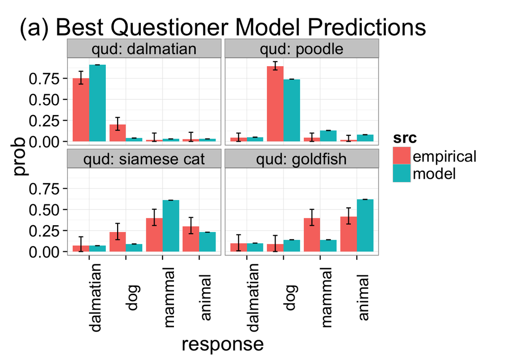

```r
questionComparison <- function(fitted_data) {
  new_labels = as.factor(sapply(X = fitted_data$qud, FUN = function(v) {return(paste("qud:", v))}))
  fitted_data$facet_label = ordered(new_labels,
                               levels = c("qud: dalmatian", "qud: poodle",
                                          "qud: siamese cat", "qud: goldfish"))
  q_comparison <- fitted_data %>%
    select(qud, response, emp_prob, upper_ci, lower_ci, model_prob, facet_label) %>%
    rename(empirical = emp_prob, model = model_prob) %>%
    gather(src, prob, empirical, model)

  # Hack to set confidence intervals to 0 for the model
  q_comparison[q_comparison$src == "model",]$upper_ci = q_comparison[q_comparison$src == "model",]$prob
  q_comparison[q_comparison$src == "model",]$lower_ci = q_comparison[q_comparison$src == "model",]$prob

  #jpeg(filename="../writing/2015/cogsci/questionerDataComparison.jpeg")

  dodge <- position_dodge(width=0.9)
  g4<-(ggplot(q_comparison, aes(x=response, y=prob, fill=src))
      #+ scale_y_continuous(limits = c(0,.3))
      + geom_bar(stat='identity', position=dodge)
      + geom_errorbar(aes(ymax = upper_ci, ymin = lower_ci),
                      position=dodge, width = .25)
      + theme_bw(base_size = 20)
      + theme(axis.text.x = element_text(angle=90, vjust=1))
      + ggtitle("(a) Best Questioner Model Predictions")
      + facet_wrap(~facet_label))
  g4
#  dev.off()
}

questionComparison(fitted_data = (prag_quest_fits %>% rename(model_prob =pragmatic_prob)))
```

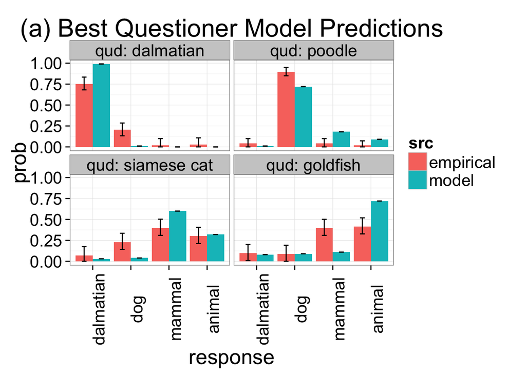

```r
questionComparison(fitted_data = (exp_quest_fits %>% rename(model_prob = explicit_prob)))
```

```r
new_labels = as.factor(sapply(X = prag_ans_fits$utterance, FUN = function(v) {return(paste("utterance:", v))}))
prag_ans_fits$facet_label = ordered(new_labels,
                              levels = c("utterance: dalmatian", "utterance: dog",
                                         "utterance: mammal","utterance: animal"))
a_comparison <- prag_ans_fits %>%
  select(utterance, response, emp_prob, upper_ci, lower_ci, pragmatic_prob, facet_label) %>%
  rename(empirical = emp_prob, model = pragmatic_prob) %>%
  gather(src, prob, empirical, model)

a_comparison[a_comparison$src == "model",]$upper_ci = a_comparison[a_comparison$src == "model",]$prob
a_comparison[a_comparison$src == "model",]$lower_ci = a_comparison[a_comparison$src == "model",]$prob
jpeg(filename="../writing/2015/cogsci/answererDataComparison.jpeg")

dodge <- position_dodge(width=0.9)
g4<-(ggplot(a_comparison, aes(x=response, y = prob, fill=src))
     + geom_bar(stat='identity', position=position_dodge())
     + geom_errorbar(aes(ymax = upper_ci, ymin = lower_ci),
                    position=dodge, width = .25)
     + theme_bw(base_size = 20)
     + theme(axis.text.x = element_text(angle=90, vjust=1))
     + ggtitle("(b) Best Answerer Model Predictions")
     + facet_wrap(~facet_label))
g4
dev.off()
```